# Simple Linear Regression

## Background

I chose Washington state since that is the state that I am from! My question that I want to answer from the data collected is, “Is there a linear relationship between the students that come from Washington state and total enrollment of the university?” I realize that the western states are more likely to have a bulk of the BYU-Idaho students and so I thought that it could be likely that there was a linear relationship. If there is a linear relationship, then one could predict total enrollment based on the amount of student from Washington state that are enrolled.

#### Hypothesis

$$H_o: \beta_1 = 0$$
$$H_a: \beta_1≠ 0$$
$$\alpha = .05$$

The above formulas constitutes my hypothesis. The null states that the slope is 0 and there is no linear relationship. The alternative states that the slope is not 0 and there is a linear relationship. I will set my significance level at .05.

```r
library(readr)
library(tidyverse)
library(pander)

##Import data
dat <- read_csv("/Users/andreasmartinson/Documents/School/1 - 2018 Fall Semester Classwork/MATH 325/Analysis 7 Data.csv")

##Spread campus data into columns
dat <- dat %>%
  spread(key = Enrollment_Type, value = Campus)

##Rename the columns
colnames(dat)[which(names(dat) == "Total")] <- "Total_CampusEnrolled"
colnames(dat)[which(names(dat)== "Washington")] <- "Washington_CampusEnrolled"
```

## Linear Plot of the Data

[figure not shown]

```r
##Plot the data
dat.lm <- lm(Total_CampusEnrolled ~ Washington_CampusEnrolled, data = dat)
plot(Total_CampusEnrolled ~ Washington_CampusEnrolled, data = dat, main = "Linear Plot of BYU-I Enrollment", xlab = "Campus Students Enrolled from Washington State",
ylab = "Total Campus Students Enrolled")
abline(dat.lm)
```

```r
##Find the x and y values
pander(dat.lm)
```

Fitting linear model: Total_CampusEnrolled ~ Washington_CampusEnrolled

|  | Estimate | Std. Error | t value | Pr(>\|t\|) |
| --- | --- | --- | --- | --- |
| **(Intercept)** | 5580 | 3222 | 1.732 | 0.1069 |
| **Washington_CampusEnrolled** | 7.755 | 2.757 | 2.813 | 0.01466 |

#### Explanation

$$\hat{Y_i} = 5580.331 + 7.755X_i$$
$$\underbrace{E\left\{Y \right\}}_\text{Number of campus students enrolled} = \overbrace{\beta_0}^\text{intercept} + \overbrace{\beta_1}^\text{slope}\underbrace{X_i}_\text{enrolled student}$$

## Testing the Assumptions

The five assumptions that need to be tested before the residual plot above can be trusted are:

1. The regression relation between Y and X is linear.
2. The error terms are normally distributed with E{ϵi}=0.
3. The variance of the error terms is constant over all X values.
4. The X values can be considered fixed and measured without error.
5. The error terms are independent.

I will test these most of these assumptions below.

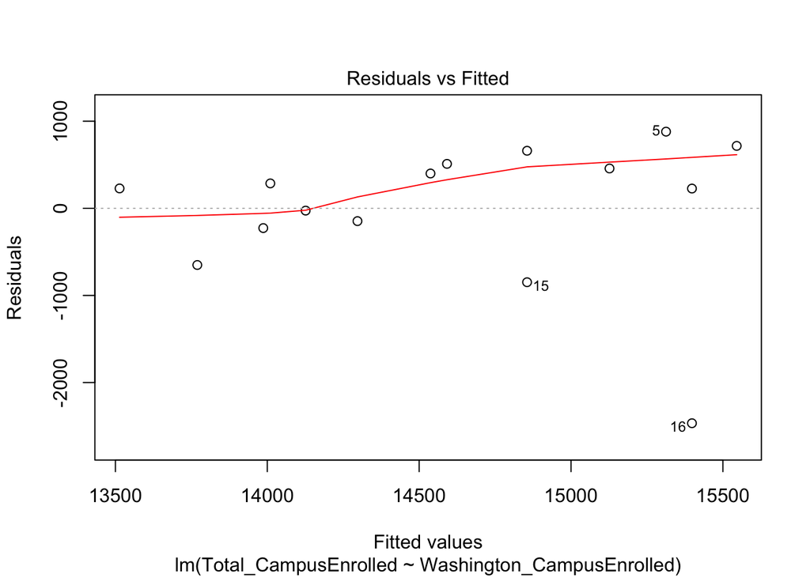

```r
##Test the assumptions
plot(dat.lm, which = 1)
```

#### Residual v. Fitted Plot

The above diagnostic plot tests assumptions 1 and 3. In order to prove these assumptions, the line above should be relatively flat and the data points should not follow a distinguishable pattern. In the data above the data points seem to be fanning out and therefore we cannot assume the regression relation between x and y is linear or that the variance of the error terms are constant. This means that we cannot use the results of the linear regression for further insight into the data.

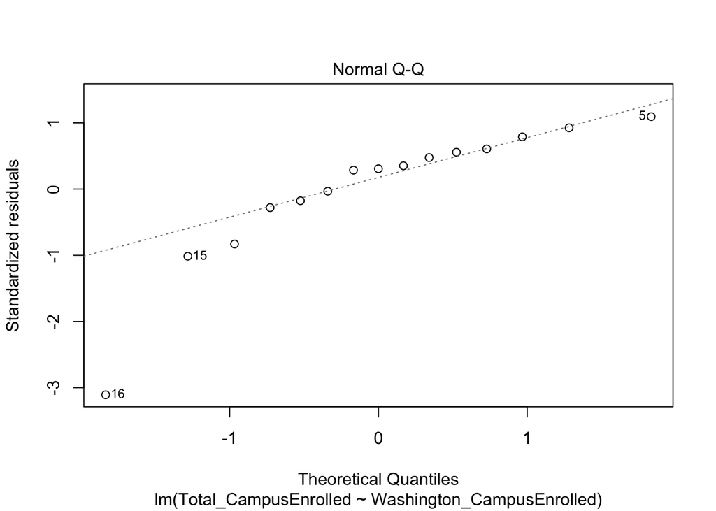

```r
##Test the assumptions
plot(dat.lm, which = 2)
```

#### QQ Plot

The above diagnostic tests assumption 2. Based on the plot above, it seems that the data is relatively normal, but points 15 and 16 make the dataset not normal, therefore the dataset fails this assumption as well.

## Conclusion

After testing 3 out of the 5 assumptions, I found that the data is not sufficient for a linear regression test since it failed assumptions 1-3. If there was more data, then the data might be found to be significant and a linear relationship might be found, but that was not so in this case.